# Final Paper

Author

Giovanni Rivera

Published

August 23, 2023

# Obtaining the data

```r
if (!require(data.table)) {
  install.packages("data.table")
  library(data.table)
}
df <- fread("vehicles.csv")
```

# Data Dictionary

Columns in the vehicles data set

| position | name | description |
| --- | --- | --- |
| 1 | id | entry ID |
| 2 | url | listing URL |
| 3 | region | craigslist region |
| 4 | region_url | region URL |
| 5 | price | entry price |
| 6 | year | entry year |
| 7 | manufacturer | manufacturer of vehicle |
| 8 | model | model of vehicle |
| 9 | condition | condition of vehicle |
| 10 | cylinders | number of cylinders |
| 11 | fuel | fuel type |
| 12 | odometer | miles traveled by vehicle |
| 13 | title_status | title status of vehicle |
| 14 | transmission | transmission of vehicle |
| 15 | vin | vehicle identification number |
| 16 | drive | type of drive |
| 17 | size | size of vehicle |
| 18 | type | generic type of vehicle |
| 19 | paint_color | color of vehicle |
| 20 | image_url | image URL |
| 21 | description | listed description of vehicle |
| 22 | county | useless column left in by mistake |
| 23 | state | state of listing |
| 24 | lat | latitude of listing |
| 25 | long | longitude of listing |
| 26 | posting_date | date of craigslist listing |

# Data Description

## Part 1: Numerical Description

```r
names(df)
```

```
 [1] "id"           "url"          "region"       "region_url"   "price"
 [6] "year"         "manufacturer" "model"        "condition"    "cylinders"
[11] "fuel"         "odometer"     "title_status" "transmission" "VIN"
[16] "drive"        "size"         "type"         "paint_color"  "image_url"
[21] "description"  "county"       "state"        "lat"          "long"
[26] "posting_date"
```

```r
library(tidyverse)
df <- df |> select(-lat,-long,-id,-url,-region_url,-VIN)
```

```r
names(df)
```

```
 [1] "region"       "price"        "year"         "manufacturer" "model"
 [6] "condition"    "cylinders"    "fuel"         "odometer"     "title_status"
[11] "transmission" "drive"        "size"         "type"         "paint_color"
[16] "image_url"    "description"  "county"       "state"        "posting_date"
```

```r
str(df)
```

```
Classes 'data.table' and 'data.frame':  426880 obs. of  20 variables:
 $ region      : chr  "prescott" "fayetteville" "florida keys" "worcester / central MA" ...
 $ price       :integer64 6000 11900 21000 1500 4900 1600 1000 15995 ...
 $ year        : int  NA NA NA NA NA NA NA NA NA NA ...
 $ manufacturer: chr  "" "" "" "" ...
 $ model       : chr  "" "" "" "" ...
 $ condition   : chr  "" "" "" "" ...
 $ cylinders   : chr  "" "" "" "" ...
 $ fuel        : chr  "" "" "" "" ...
 $ odometer    : int  NA NA NA NA NA NA NA NA NA NA ...
 $ title_status: chr  "" "" "" "" ...
 $ transmission: chr  "" "" "" "" ...
 $ drive       : chr  "" "" "" "" ...
 $ size        : chr  "" "" "" "" ...
 $ type        : chr  "" "" "" "" ...
 $ paint_color : chr  "" "" "" "" ...
 $ image_url   : chr  "" "" "" "" ...
 $ description : chr  "" "" "" "" ...
 $ county      : logi  NA NA NA NA NA NA ...
 $ state       : chr  "az" "ar" "fl" "ma" ...
 $ posting_date: POSIXct, format: NA NA ...
 - attr(*, ".internal.selfref")=<externalptr>
```

```r
df$state <-as.factor(df$state)
```

```r
str(df)
```

```
Classes 'data.table' and 'data.frame':  426880 obs. of  20 variables:
 $ region      : chr  "prescott" "fayetteville" "florida keys" "worcester / central MA" ...
 $ price       :integer64 6000 11900 21000 1500 4900 1600 1000 15995 ...
 $ year        : int  NA NA NA NA NA NA NA NA NA NA ...
 $ manufacturer: chr  "" "" "" "" ...
 $ model       : chr  "" "" "" "" ...
 $ condition   : chr  "" "" "" "" ...
 $ cylinders   : chr  "" "" "" "" ...
 $ fuel        : chr  "" "" "" "" ...
 $ odometer    : int  NA NA NA NA NA NA NA NA NA NA ...
 $ title_status: chr  "" "" "" "" ...
 $ transmission: chr  "" "" "" "" ...
 $ drive       : chr  "" "" "" "" ...
 $ size        : chr  "" "" "" "" ...
 $ type        : chr  "" "" "" "" ...
 $ paint_color : chr  "" "" "" "" ...
 $ image_url   : chr  "" "" "" "" ...
 $ description : chr  "" "" "" "" ...
 $ county      : logi  NA NA NA NA NA NA ...
 $ state       : Factor w/ 51 levels "ak","al","ar",..: 4 3 10 20 28 35 35 35 38 39 ...
 $ posting_date: POSIXct, format: NA NA ...
 - attr(*, ".internal.selfref")=<externalptr>
```

Manufactures & Paint Color

This contingency table demonstrates the frequencies of colors for each vehicle, by manufacturer.

```r
with(df,addmargins(table(paint_color,manufacturer)))
```

```
           manufacturer
paint_color         acura alfa-romeo aston-martin   audi    bmw  buick cadillac
              6051   1689        203            9   2067   3789   1799     2059
     black    1616   1004        217            5   1934   3806    675     1659
     blue     1160    307        164            3    719   1439    292      288
     brown     182     73          9            0     65    157    235      110
     custom    282     74         17            0     44    137    128      143
     green     597     26          4            2     51     97     57       39
     grey      687    367         11            1    563    892    218      224
     orange    155      1          1            0      4     36      2        5
     purple     67      2          0            0      2     13     18       10
     red      1642    239         94            0    185    376    508      435
     silver   1086    915         28            2    955   1501    550      686
     white    3785   1279        149            2    974   2436   1013     1275
     yellow    336      2          0            0     10     20      6       20
     Sum     17646   5978        897           24   7573  14699   5501     6953
           manufacturer
paint_color chevrolet chrysler datsun  dodge ferrari   fiat   ford    gmc
                16989     2160     25   4468      40    314  21549   5468
     black       7225      813      2   2253       9     89   8573   3005
     blue        3660      512      9    944       0     31   4711    870
     brown       1016       94      3     83       0     19    917    441
     custom       839      130      2    186       2     33   1173    240
     green        744       58      2    352       0     32   1295    144
     grey        2437      380      2    916       2     36   3282    670
     orange       251        4      4    215       0      4    330     12
     purple        95        9      0     70       0      0     77     13
     red         5281      336      7   1098      30     71   5167    979
     silver      4927      800      3   1087       3     24   4929   1078
     white      11075      713      4   1980       8    133  18609   3804
     yellow       525       22      0     55       1      6    373     61
     Sum        55064     6031     63  13707      95    792  70985  16785
           manufacturer
paint_color harley-davidson  honda hyundai infiniti jaguar   jeep    kia
                         40   6421    2982     1345    448   6107   2643
     black               86   2753    1242     1070    518   3266   1246
     blue                 5   2106    1170      639    207   1008    494
     brown                0    414     155      178     16    249    221
     custom               4    440     167       74     19    313    146
     green                0    374      67       30     88    688    225
```

[output cut: 41 more lines]

```
paint_color subaru  tesla toyota volkswagen  volvo    Sum
              2858    215  10066       2494   1192 130203
     black     807     72   3584       1671    512  62861
     blue     1508     81   2312       1053    324  31223
     brown     102      2    556         77     49   6593
     custom    137      1    698         95     58   6700
     green     422      3    820        102     43   7343
     grey      693     28   2748        646    186  24416
     orange     71      0     53         63      3   1984
     purple      9      0     37          8      1    687
     red       553     30   2853        610    159  30473
     silver   1217     41   5120       1031    384  42970
     white    1107    394   5267       1424    457  79285
     yellow     11      1     88         71      6   2142
     Sum      9495    868  34202       9345   3374 426880
```

Title Status and Contion

This contingency table demonstrates the frequencies of title status’s of each vehicle based on their condition.

A vehicle’s title status could directly correlate and be impacted by its condition. The most common title status is a clean status followed by a rebuilt status.

```r
with(df,addmargins(table(condition,title_status)))
```

```
           title_status
condition           clean   lien missing parts only rebuilt salvage    Sum
              2759 167445    107     299         70    2048    1376 174104
  excellent   5369  91734    586      57         18    2823     880 101467
  fair           0   6156     47     188         27     142     209   6769
  good         114 118461    389     208         29    1362     893 121456
  like new       0  19870    265       8          9     791     235  21178
  new            0   1226     25       5          4      30      15   1305
  salvage        0    225      3      49         41      23     260    601
  Sum         8242 405117   1422     814        198    7219    3868 426880
```

Title Status and State

This contingency table demonstrates the frequency of title status’s by State.

```r
with(df,addmargins(table(state,title_status)))
```

```
     title_status
state         clean   lien missing parts only rebuilt salvage    Sum
  ak       0   3313     30       6          2     112      11   3474
  al     153   4668     20       7          1     101       5   4955
  ar      13   3911      8      11          0      83      12   4038
  az     145   8285     43      17          4     108      77   8679
  ca    1620  47512     97     112         32     181    1060  50614
  co     131  10694     53      17          3     127      63  11088
  ct      10   5097      5      25          2      44       5   5188
  dc      26   2899      4       7          2      18      14   2970
  de       0    932      3       2          0      10       2    949
  fl     493  27331     67      51         13     500      56  28511
  ga      21   6887     26      17          2      33      17   7003
  hi      91   2823      6       4          1      29      10   2964
  ia     292   7380     25       5          3     764     163   8632
  id      59   8603     35      10          5     188      61   8961
  il     187  10009     26      12          0     129      24  10387
  in       0   5509     19       5          1     157      13   5704
  ks      78   5908     20       8          7     145      43   6209
  ky      10   3880     16       6          2     217      18   4149
  la      20   3070     12       4          0      62      28   3196
  ma     138   7835     11      16          6     149      19   8174
  md      26   4666     12       7          5      33      29   4778
  me       1   2900     16      21          3      20       5   2966
  mi    1036  15404     91      22          4     251      92  16900
  mn      71   7212     32      18          6     228     149   7716
  mo       1   4167     23      16          2      62      22   4293
  ms      26    960      9       3          0      13       5   1016
  mt      78   6069     47      20          3      44      33   6294
  nc     606  13953     60      29         14     338     277  15277
  nd       0    403      3       0          2       0       2    410
  ne       1    973      4       3          0      23      32   1036
  nh       2   2922     17      20          4      13       3   2981
  nj      26   9511      8      13          3     130      51   9742
  nm      23   4193     21      16          2      20     150   4425
  nv      16   3073      9       9          0      65      22   3194
  ny      79  18986     87      38          7     114      75  19386
  oh     449  16735     36       8          7     363      98  17696
  ok       1   6647     36       9          1      76      22   6792
  or     192  16513     29      30          3     217     120  17104
  pa     290  12902     20      12          9     294     226  13753
  ri       0   2279      3      15          5      11       7   2320
  sc      66   5975     25       4          2      60     195   6327
  sd       0   1216     13       4          0      15      54   1302
  tn     265  10301     34      24          8     380      54  11066
  tx     112  21796     66      70         15     638     248  22945
  ut      20    995      6       1          0      99      29   1150
  va     181  10357     59       7          2     106      20  10732
  vt      18   2417      9      28          1      35       5   2513
  wa    1026  12584     22      12          1     174      42  13861
  wi     143  10869     93      10          2     208      73  11398
  wv       0   1015      2       2          1      11      21   1052
  wy       0    578      4       1          0      21       6    610
  Sum   8242 405117   1422     814        198    7219    3868 426880
```

```r
library(tidyverse)
df <- df[df$price<100000&df$price>0,]
dfd<-df |> select("price", "cylinders", "odometer", "size", "manufacturer")
dfd$size<-as.factor(dfd$size)
dfd$price<-as.factor(dfd$price)
dfd$odometer<-as.factor(dfd$odometer)
dfd$cylinders<-as.factor(dfd$cylinders)
```

Summary of price ranging from 1 to 99999.

```r
df$price <- as.integer(df$price)
summary(df$price)
```

```
   Min. 1st Qu.  Median    Mean 3rd Qu.    Max.
      1    7000   15000   18709   27590   99999
```

Before sorting the price range to be between 0 and 100000 the outrageously high prices dragged the mean above the median, however on setting a price range, the mean is now closer to the median and they provide a certain amount of accuracy.The mean here is 18709 and the median is 15000.

Stem plot of odometer.

```r
dfd$odometer<- as.numeric(dfd$odometer)
stem(dfd$odometer[1:100])
```

```
  The decimal point is 4 digit(s) to the right of the |

  0 | 011133334444455556667778888899
  1 | 02333444555578888999
  2 | 0111222888
  3 | 025669
  4 | 15699
  5 | 002
  6 | 7
  7 | 5
  8 | 6
  9 | 0
```

Count of cylinders

```r
dfd |> count(cylinders,sort=TRUE)
```

```
      cylinders      n
1:              160154
2:  6 cylinders  88781
3:  4 cylinders  72995
4:  8 cylinders  66484
5:  5 cylinders   1668
6: 10 cylinders   1344
7:        other   1081
8:  3 cylinders    611
9: 12 cylinders    170
```

This representation shows that majority of the users did not fill in an answer for cylinders, however of those that did, “6 cylinders” are the most popular.

Contingency table between manufacturer and cylinders.

```r
dfA<- subset (df, manufacturer %in% c("ford", "honda", "toyota", "chevrolet", "nissan"))
dfB<- subset (dfA, cylinders %in% c("10 cylinders", "12 cylinders", "3 cylinders", "4 cylinders", "5 cylinders","6 cylinders", "8 cylinders"))
tbl<- table(dfA$manufacturer, dfA$cylinders)
addmargins(tbl)
```

```
                   10 cylinders 12 cylinders 3 cylinders 4 cylinders
  chevrolet  18602           28            2          39        6414
  ford       26028          929            3         119        7514
  honda       7386            7            0          47        8686
  nissan      6600           26            0           5        5571
  toyota     11585            8            0          10        9067
  Sum        70201          998            5         220       37252

            5 cylinders 6 cylinders 8 cylinders  other    Sum
  chevrolet         144        7215       18001     91  50536
  ford               29       12922       17144    125  64813
  honda              14        3685          12     29  19866
  nissan              3        3998        1098     90  17391
  toyota              9        8092        2788     37  31596
  Sum               199       35912       39043    372 184202
```

On observing the cylinders of the most popular manufacturers, we can see that chevrolet and ford have 8 cylinders as their most produced whereas honda, nissan, and toyota have 4 cylinders as their most produced.

Contingency table between size and manufacturer.

```r
dfX<- subset (df, size %in% c("compact", "full-size", "mid-size", "sub-compact"))
dfY<- subset (dfX, manufacturer %in% c("ford", "honda", "toyota", "chevrolet", "nissan"))
tbl<- table(dfY$size, dfY$manufacturer)
addmargins(tbl)
```

```
              chevrolet  ford honda nissan toyota   Sum
  compact          1685  1579  1650   1063   1631  7608
  full-size       10351 13748  2284   1969   3785 32137
  mid-size         3032  3835  2614   2097   3615 15193
  sub-compact       237   496   302    101    183  1319
  Sum             15305 19658  6850   5230   9214 56257
```

The entire data set has too many manufacturers to clearly analyze the data so I’ve chosen 5 of the most popular manufacturers. On short-listing the most popular manufacturers and comparing their respective sizes, it is clear to see that the most popular size in Chevrolet, Ford, and Toyota is “full-size” whereas in Honda and Nissan it is “mid-size” .

Number of vehicles from each year

```r
df |> count(year,sort=TRUE)
```

```
     year     n
  1: 2018 32563
  2: 2017 32463
  3: 2013 28188
  4: 2015 27945
  5: 2016 27376
 ---
109: 1905     1
110: 1909     1
111: 1915     1
112: 1918     1
113: 1943     1
```

Number of Vehicles from each manufacturer

```r
df |> count(manufacturer,sort=TRUE)
```

```
       manufacturer     n
 1:            ford 64813
 2:       chevrolet 50536
 3:          toyota 31596
 4:           honda 19866
 5:            jeep 17449
 6:          nissan 17391
 7:             ram 16443
 8:                 15988
 9:             gmc 15420
10:             bmw 13738
11:           dodge 12325
12:   mercedes-benz 10391
13:         hyundai  9374
14:          subaru  8984
```

[output cut: 30 more lines]

Number of Vehicles from each model

```r
df |> count(model,sort=TRUE)
```

```
                             model    n
    1:                       f-150 7115
    2:                             4600
    3:              silverado 1500 4546
    4:                        1500 3800
    5:                       camry 2827
   ---
28133:                         Х5М    1
28134:                  sorento lx    1
28135:                          ♿    1
28136:        𝓜𝓮𝓻𝓬𝓮𝓭𝓮𝓼 𝓫𝓮𝓷𝔃 𝓶𝓵 350    1
28137: 🔥GMC Sierra 1500 SLE🔥 4X4 🔥    1
```

Number of Vehicles from each type of drive

```r
df |> count(drive,sort=TRUE)
```

```
   drive      n
1:   4wd 120500
2:       119969
3:   fwd  97602
4:   rwd  55217
```

contingency table comparing manufacturers and drive of vehicles

```r
with(df,table(manufacturer,drive))
```

```
                 drive
manufacturer              4wd   fwd   rwd
                   6240  2141  3149  4458
  acura            2569   840  2255    38
  alfa-romeo        585    61     4   220
  aston-martin        2     0     0    16
  audi             4154  2218   750    28
  bmw              5719  2957   272  4790
  buick            1822   558  2610   191
  cadillac         2587  1514  1409  1060
  chevrolet       14563 16394  9819  9760
  chrysler         1699   264  2775   915
  datsun             24     0     0    39
  dodge            3603  1575  3525  3622
  ferrari             5     0    17    17
  fiat              164    13   440   155
  ford            18071 25123 10317 11302
  gmc              4519  8136  1126  1639
  harley-davidson    84    12     3    39
  honda            5869  3206 10633   158
  hyundai          2842   840  5269   423
  infiniti         1697  1103   576  1095
  jaguar           1113   116    28   641
  jeep             2728 13261  1002   458
  kia              2089   678  4627   153
  land rover          2     9     0     0
  lexus            2116  1758  2378  1487
  lincoln          1268   842  1467   456
  mazda            1202   481  2222  1143
  mercedes-benz    4246  2144   483  3518
  mercury           364   142   282   349
  mini              680   180  1381    19
  mitsubishi        892  1129   873   215
  morgan              2     0     0     1
  nissan           4396  4072  7558  1365
  pontiac           799    58   861   511
  porsche           573   336     9   351
  ram              3726 10606   677  1434
  rover             590  1369    10     7
  saturn            409    86   486    90
  subaru           3690  5058   113   123
  tesla             190   119    14   522
  toyota           8137  9657 11806  1996
  volkswagen       2500   554  5538   304
  volvo            1439   890   838   109
```

contingency table comparing year and drive of vehicles

```r
with(df,table(year,drive))
```

```
      drive
year           4wd   fwd   rwd
  1900     9     1     2     0
  1901     2     0     0     1
  1905     0     0     0     1
  1909     1     0     0     0
  1910     2     0     0     0
  1913     0     0     0     2
  1915     0     0     0     1
  1916     1     0     0     1
  1918     0     0     0     1
  1920     1     0     0     1
  1921     1     0     0     1
  1922     1     0     0     2
  1923    10     0     0    26
```

[output cut: 99 more lines]

statistical summary of year

```r
with(df,summary(year))
```

```
   Min. 1st Qu.  Median    Mean 3rd Qu.    Max.    NA's
   1900    2008    2013    2011    2017    2022    1171
```

```r
library(tidyverse)
library(MASS)
library(pander)
```

```r
pander(addmargins(with(df,table(type,fuel))))
```

|  |  | diesel | electric | gas | hybrid | other | Sum |
| --- | --- | --- | --- | --- | --- | --- | --- |
|  | 791 | 8252 | 161 | 73953 | 815 | 1765 | 85737 |
| **bus** | 0 | 207 | 1 | 260 | 0 | 30 | 498 |
| **convertible** | 5 | 17 | 14 | 7008 | 37 | 292 | 7373 |
| **coupe** | 38 | 37 | 18 | 16355 | 39 | 1576 | 18063 |
| **hatchback** | 35 | 170 | 502 | 11302 | 1282 | 2626 | 15917 |
| **mini-van** | 41 | 18 | 0 | 4363 | 5 | 125 | 4552 |
| **offroad** | 0 | 31 | 0 | 561 | 0 | 1 | 593 |
| **other** | 47 | 888 | 52 | 14286 | 364 | 4139 | 19776 |
| **pickup** | 391 | 5851 | 3 | 28153 | 13 | 6944 | 41355 |
| **sedan** | 507 | 843 | 694 | 71005 | 1353 | 5877 | 80279 |
| **SUV** | 588 | 698 | 133 | 65163 | 494 | 3453 | 70529 |
| **truck** | 21 | 8739 | 2 | 21646 | 66 | 118 | 30592 |
| **van** | 116 | 297 | 1 | 6992 | 18 | 542 | 7966 |
| **wagon** | 10 | 193 | 42 | 8877 | 399 | 537 | 10058 |
| **Sum** | 2590 | 26241 | 1623 | 329924 | 4885 | 28025 | 393288 |

```r
pander(addmargins(with(df,table(type,transmission))))
```

|  |  | automatic | manual | other | Sum |
| --- | --- | --- | --- | --- | --- |
|  | 328 | 76979 | 7238 | 1192 | 85737 |
| **bus** | 0 | 377 | 58 | 63 | 498 |
| **convertible** | 23 | 4915 | 1573 | 862 | 7373 |
| **coupe** | 50 | 9389 | 3028 | 5596 | 18063 |
| **hatchback** | 58 | 7941 | 1639 | 6279 | 15917 |
| **mini-van** | 15 | 4478 | 44 | 15 | 4552 |
| **offroad** | 0 | 356 | 231 | 6 | 593 |
| **other** | 376 | 8400 | 801 | 10199 | 19776 |
| **pickup** | 240 | 26619 | 1336 | 13160 | 41355 |
| **sedan** | 304 | 62065 | 3426 | 14484 | 80279 |
| **SUV** | 286 | 61868 | 1885 | 6490 | 70529 |
| **truck** | 20 | 28184 | 1802 | 586 | 30592 |
| **van** | 15 | 7261 | 98 | 592 | 7966 |
| **wagon** | 101 | 7445 | 593 | 1919 | 10058 |
| **Sum** | 1816 | 306277 | 23752 | 61443 | 393288 |

```r
pander(addmargins(with(df,table(transmission,fuel))))
```

|  |  | diesel | electric | gas | hybrid | other | Sum |
| --- | --- | --- | --- | --- | --- | --- | --- |
|  | 334 | 115 | 19 | 1237 | 17 | 94 | 1816 |
| **automatic** | 2071 | 22964 | 781 | 266633 | 3800 | 10028 | 306277 |
| **manual** | 80 | 2293 | 12 | 20888 | 124 | 355 | 23752 |
| **other** | 105 | 869 | 811 | 41166 | 944 | 17548 | 61443 |
| **Sum** | 2590 | 26241 | 1623 | 329924 | 4885 | 28025 | 393288 |

## Part 2: Visual Description

**Title Status and Condition Bar Chart**

This bar chart demonstrates the count of title status’s for all vehicles which is disproportionately a clean title status, additionally it also demonstrates the condition of the vehicle.

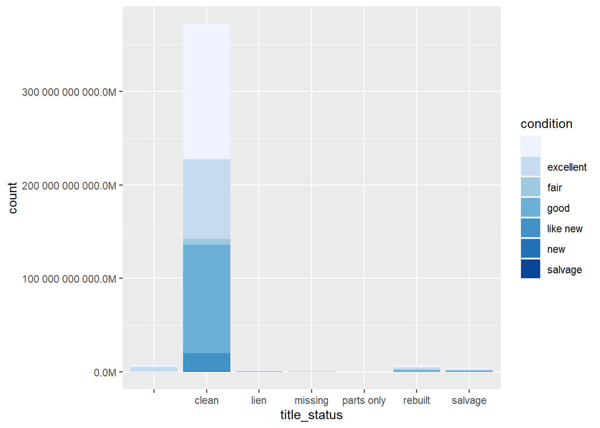

```r
df_bar <- ggplot(data = df, aes(title_status, fill = condition))
df_bar +
  geom_bar(stat = "count") +
  scale_fill_brewer() +
  scale_y_continuous(labels = scales::number_format(scale = 1e6, accuracy = 0.1, suffix = "M"))
```

**Manufacturer and Paint Color**

Demonstrates the relationship between a vehicle’s manufacturer and the vehicle’s paint color. The most common types of relationships are a vehicle being manufactured by Ford and being the color white, a vehicle being manufactured by Chevrolet and being the color white, and a vehicle being manufactured by Ford and being the color black.

```r
dfX_manufacturer<- subset(df, manufacturer %in% c("chevrolet", "ford", "honda", "nissan"))
dfY_manufacturer<- subset(dfX_manufacturer, paint_color %in% c("white", "black", "silver", "red"))
```

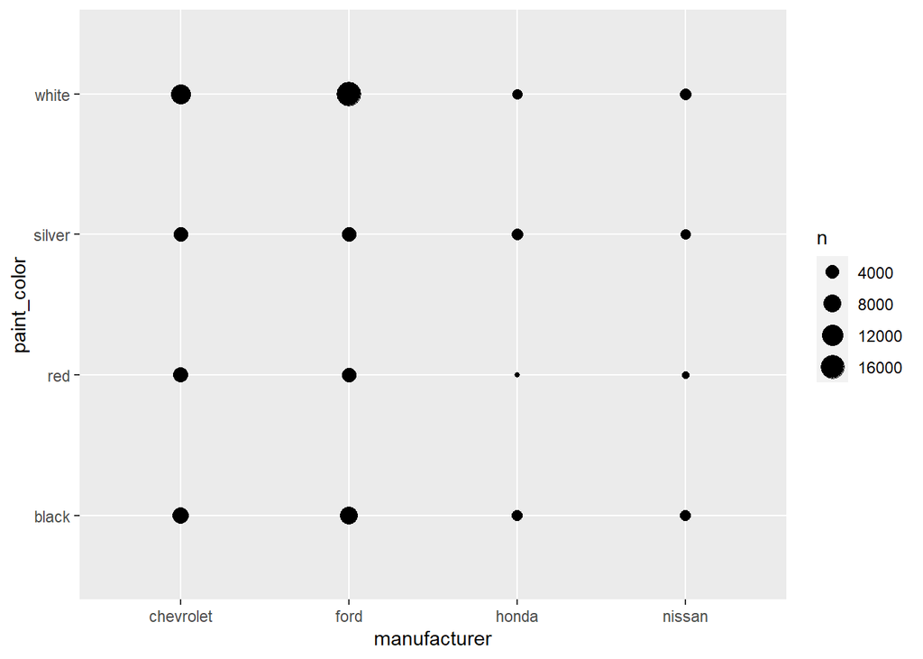

```r
g_manufacturer <- ggplot(data = dfY_manufacturer, aes(manufacturer, paint_color))
g_manufacturer + geom_count()
```

**Title Status and State**

Demonstrates the title status of the top three states with the highest number of vehicles. The vehicles title statuses are overwhelmingly a clean title status.

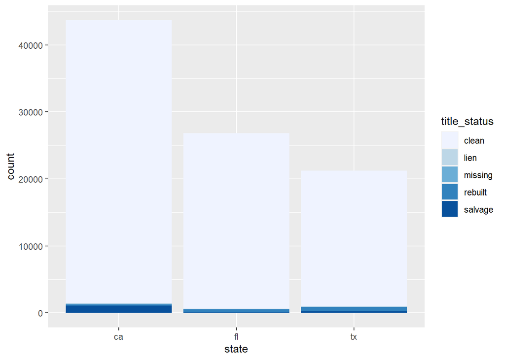

```r
dfX_state<- subset (df, state %in% c("tx", "ca", "fl"))
dfY_state<- subset (dfX_state, title_status %in% c("clean", "lien", "missing", "rebuilt", "salvage"))

df_state <- ggplot(data = dfY_state, aes(state,fill=title_status))
df_state + geom_bar(stat = "count") + scale_fill_brewer()
```

**Number of Vehicles from each year**

```r
stem(df$year)
```

```
  The decimal point is 1 digit(s) to the right of the |

  190 | 00000000000011159
  191 | 00335668
  192 | 00112223333333333333333333333333333333333334444444445555555566666666+124
  193 | 00000000000000000000000000000000000000000000000000000000000000000001+384
  194 | 00000000000000000000000000000000000000000000000000000000000000000000+387
  195 | 00000000000000000000000000000000000000000000000000000000000000000000+1109
  196 | 00000000000000000000000000000000000000000000000000000000000000000000+2670
  197 | 00000000000000000000000000000000000000000000000000000000000000000000+2964
  198 | 00000000000000000000000000000000000000000000000000000000000000000000+3838
  199 | 00000000000000000000000000000000000000000000000000000000000000000000+12537
  200 | 00000000000000000000000000000000000000000000000000000000000000000000+92977
  201 | 00000000000000000000000000000000000000000000000000000000000000000000+254578
  202 | 00000000000000000000000000000000000000000000000000000000000000000000+19644
```

**Type of Model Visualization**

```r
df$model<-as.numeric(df$model)
stem(df$model)
```

```
  The decimal point is 4 digit(s) to the right of the |

  -0 | 0
   0 | 00000000000000000000000000000000000000000000000000000000000000000000+11205
   1 |
   2 | 15
   3 | 9
   4 |
   5 |
   6 |
   7 |
   8 |
   9 | 3558
  10 | 08
  11 |
  12 | 3
  13 | 35
  14 | 2
  15 | 8
  16 | 4
  17 | 0
  18 |
  19 |
  20 | 00
  21 |
  22 |
  23 |
  24 | 8
```

**Vehicle manufacturer and drive of the cars**

This is a visualization in the form of a stacked bar chart comparing vehicle manufacturer and drive of the cars in the data set for the top manufacturers .

```r
dfmanufacturerx <- subset(df, manufacturer %in% c("ford", "honda", "chevrolet", "nissan", "toyota"))
```

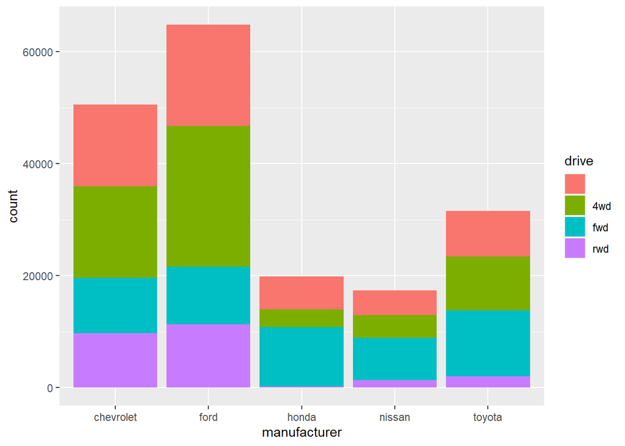

```r
ggplot(data = dfmanufacturerx, aes(x = manufacturer, fill = drive)) +
    geom_bar(stat = "count")
```

**Comparing vehicle manufacturer and model**

This is a visualization in the form of a stacked bar chart comparing vehicle manufacturer and model of the cars in the data set.

[figure not shown]

```r
df$model<-as.factor(df$model)
ggplot(data = df, aes(manufacturer, fill = model)) +
    geom_bar(stat = "count")
```

**Comparing vehicle year and drive**

This is a visualization in the form of a stacked bar chart comparing vehicle year and drive of the cars in the data set.

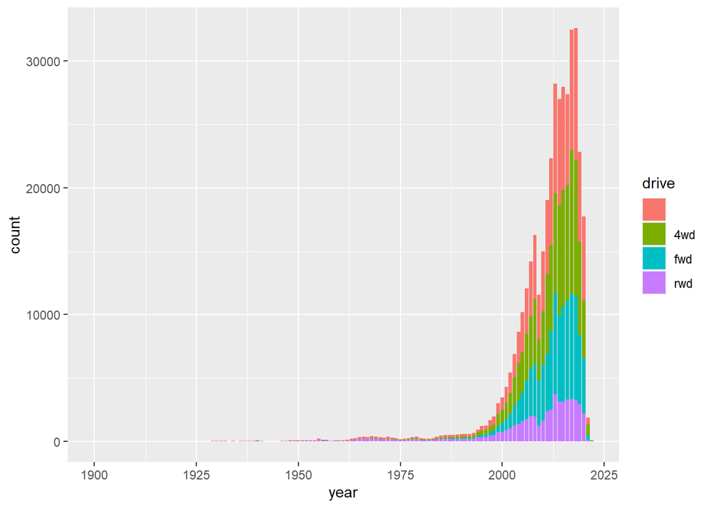

```r
ggplot(data = df, aes(x = year, fill = drive)) +
    geom_bar(stat = "count")
```

**Manufacturer and Price**

These are bar graphs showing the relationship between manufacturer and total price, and manufacturer and average price.

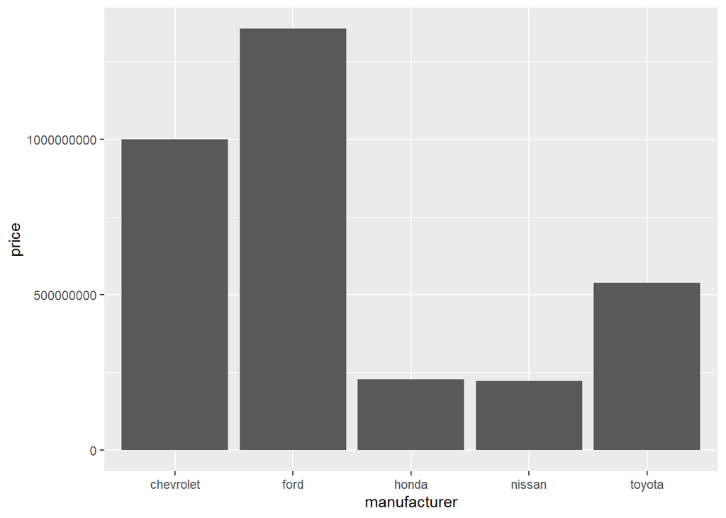

```r
df <- df[df$price<500000&df$price>500,]
df<- subset (df, manufacturer %in% c("ford", "honda", "toyota", "chevrolet", "nissan"))
df$price<-as.numeric(df$price)
options(scipen=999)
f <- ggplot(df,aes(manufacturer,price))
f + geom_col() + scale_fill_manual(values=c(("lightblue"),("darkblue"),("pink"),("yellow"),("red")))
```

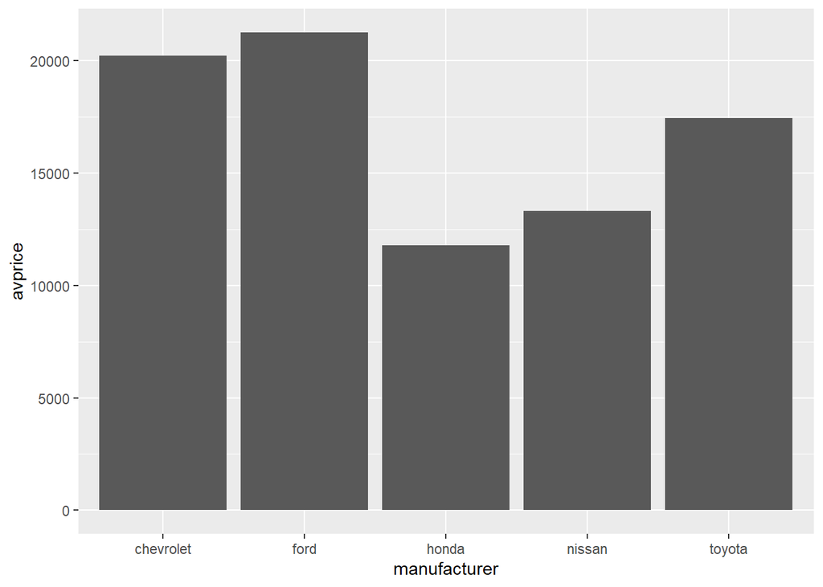

```r
dfa <- df |> group_by(manufacturer) |>
  summarize(avprice = mean(price))
ggplot(dfa,aes(manufacturer,avprice))+geom_col() + scale_fill_manual(values=c(("lightblue"),("darkblue"),("pink"),("yellow"),("red")))
```

From this we can clearly see that a car manufactured by ford is on average more expensive than the others in comparisions, and one manufactured by honda is cheaper.

**Manufacturer and Cylinders** A bar graph showing the relationship between manufacturers and cylinders.

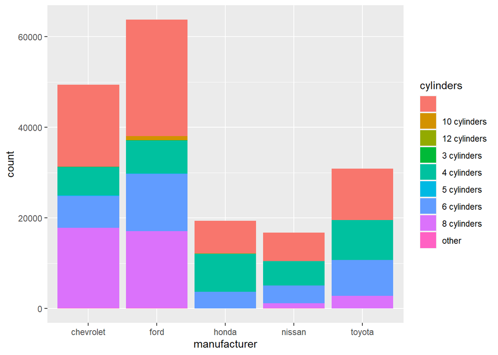

```r
df<- subset (df, manufacturer %in% c("ford", "honda", "toyota", "chevrolet", "nissan"))
ggplot(df, aes(x = manufacturer, fill=cylinders)) +
    geom_bar(stat = "count")
```

**Odometer and Size** A box plot showing the rlationship between type of car and odometer, with outliers removed for accuracy.

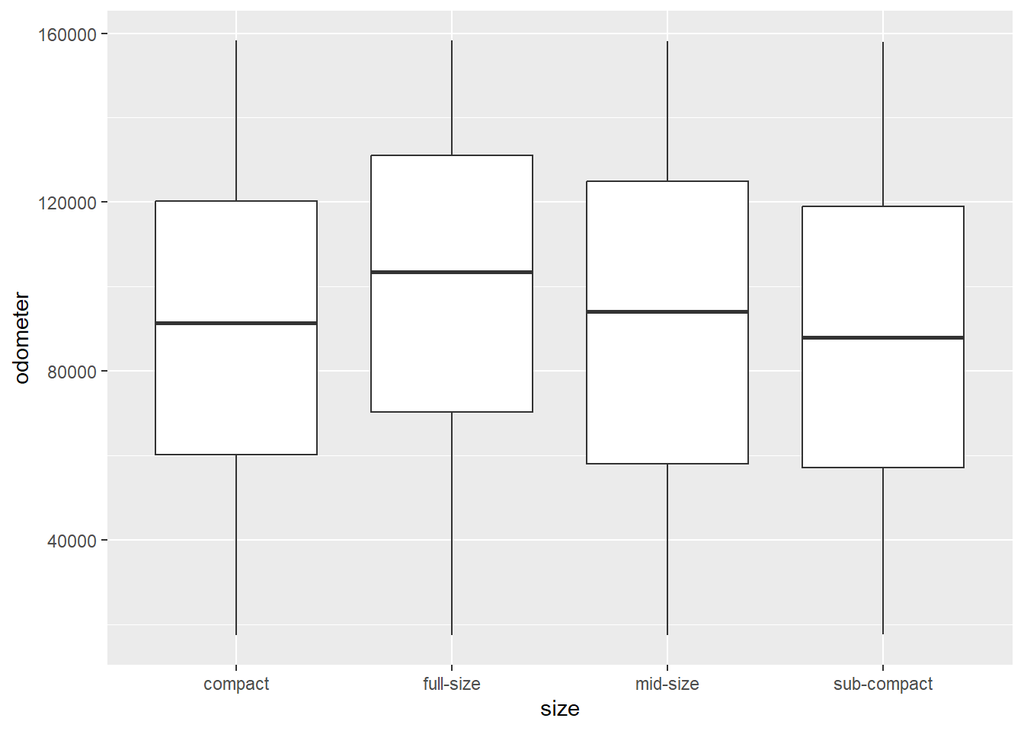

```r
dfC<- subset (df, size %in% c("compact", "full-size", "mid-size", "sub-compact"))
dfC |> ggplot(aes(size,odometer))+geom_boxplot(outlier.shape=NA)+  scale_y_continuous(limits = quantile(df$odometer, c(0.1, 0.8),na.rm=TRUE))
```

We can see how the median of the odometer values for all types of cars is very similar.

**Type and Price**

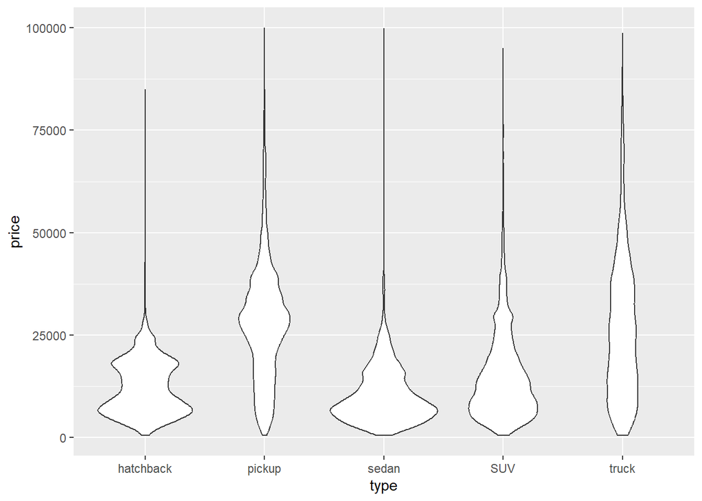

```r
df <- df[df$price<500000&df$price>500,]
df<- subset (df, type %in% c("pickup", "sedan", "SUV", "truck", "hatchback"))
ggplot(df,aes(type,price)) + geom_violin(scale = "area")
```

The above violin plot demonstrates a visual representation of the distribution of the price of vehicle based on the type of vehicle, from the violin plot we can infer the median, interquartile range, and the shape of the distribution of prices of vehicles based on vehicle type. For example a pickup vehicle will have a higher mean and median price compared to a sedan.

**Vehicle type and Fuel Type**

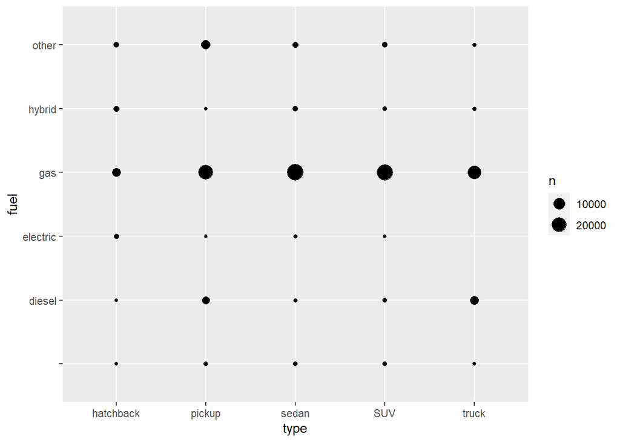

```r
df<- subset (df, type %in% c("pickup", "sedan", "SUV", "truck", "hatchback"))
ggplot(df, aes(type, fuel)) + geom_count()
```

# Regression Analysis

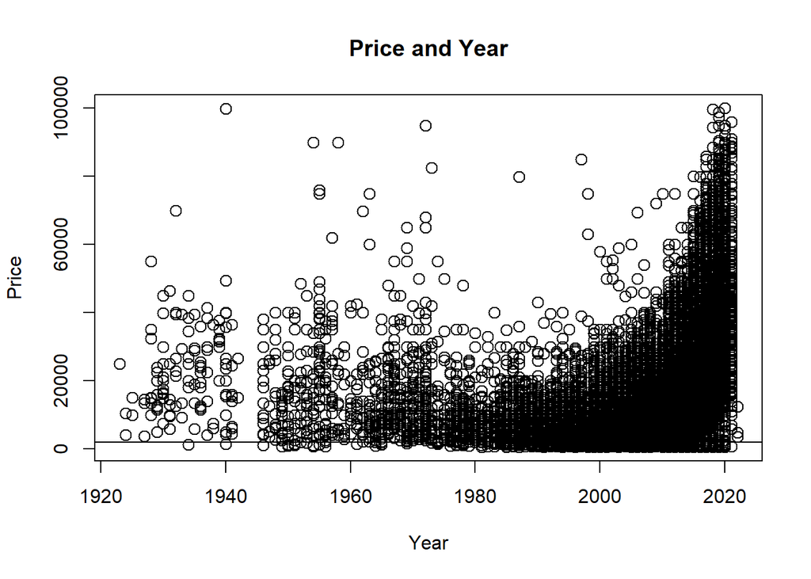

```r
plot(df$year,df$price,col = "black",main = "Price and Year",
abline(lm(df$year~df$price)),cex = 1.3,pch = 1,xlab = "Year",ylab = "Price")
```

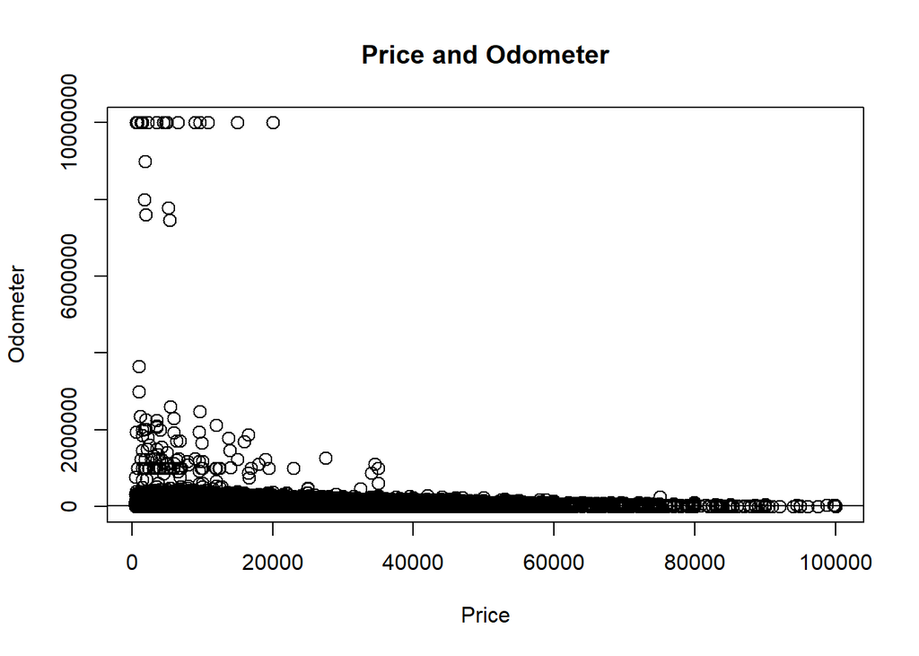

```r
plot(df$price,df$odometer,col = "black",main = "Price and Odometer",
abline(lm(df$price~df$odometer)),cex = 1.3,pch = 1,xlab = "Price",ylab = "Odometer")
```

```r
library(caret)
library(leaps)
```

```r
library(ggplot2)

model <- lm(price ~ type + cylinders + drive, data = df)

summary(model)
```

```
Call:
lm(formula = price ~ type + cylinders + drive, data = df)

Residuals:
   Min     1Q Median     3Q    Max
-32312  -6834  -1159   5719  94014

Coefficients:
                      Estimate Std. Error t value             Pr(>|t|)
(Intercept)            15067.4      178.0  84.632 < 0.0000000000000002 ***
typepickup             13234.1      184.2  71.833 < 0.0000000000000002 ***
typesedan               -581.3      161.4  -3.602             0.000316 ***
typeSUV                 1373.5      178.1   7.713   0.0000000000000124 ***
typetruck              12677.9      198.7  63.820 < 0.0000000000000002 ***
cylinders10 cylinders  -3563.8      489.7  -7.277   0.0000000000003433 ***
cylinders12 cylinders -14747.6     5803.2  -2.541             0.011046 *
cylinders3 cylinders   -3009.2      963.3  -3.124             0.001786 **
cylinders4 cylinders   -5294.1      104.2 -50.821 < 0.0000000000000002 ***
cylinders5 cylinders  -17038.9      947.9 -17.975 < 0.0000000000000002 ***
cylinders6 cylinders   -4552.9      102.4 -44.481 < 0.0000000000000002 ***
cylinders8 cylinders   -3780.7      109.7 -34.456 < 0.0000000000000002 ***
cylindersother         -3378.3      764.1  -4.421   0.0000098238119481 ***
drive4wd                4522.6      112.9  40.057 < 0.0000000000000002 ***
drivefwd                -325.8      123.6  -2.635             0.008410 **
driverwd               -4831.3      154.0 -31.368 < 0.0000000000000002 ***
---
Signif. codes:  0 '***' 0.001 '**' 0.01 '*' 0.05 '.' 0.1 ' ' 1

Residual standard error: 11600 on 111679 degrees of freedom
Multiple R-squared:  0.3368,    Adjusted R-squared:  0.3367
F-statistic:  3781 on 15 and 111679 DF,  p-value: < 0.00000000000000022
```

# Regression Diagnostics

**Residuals and Fitted Values**

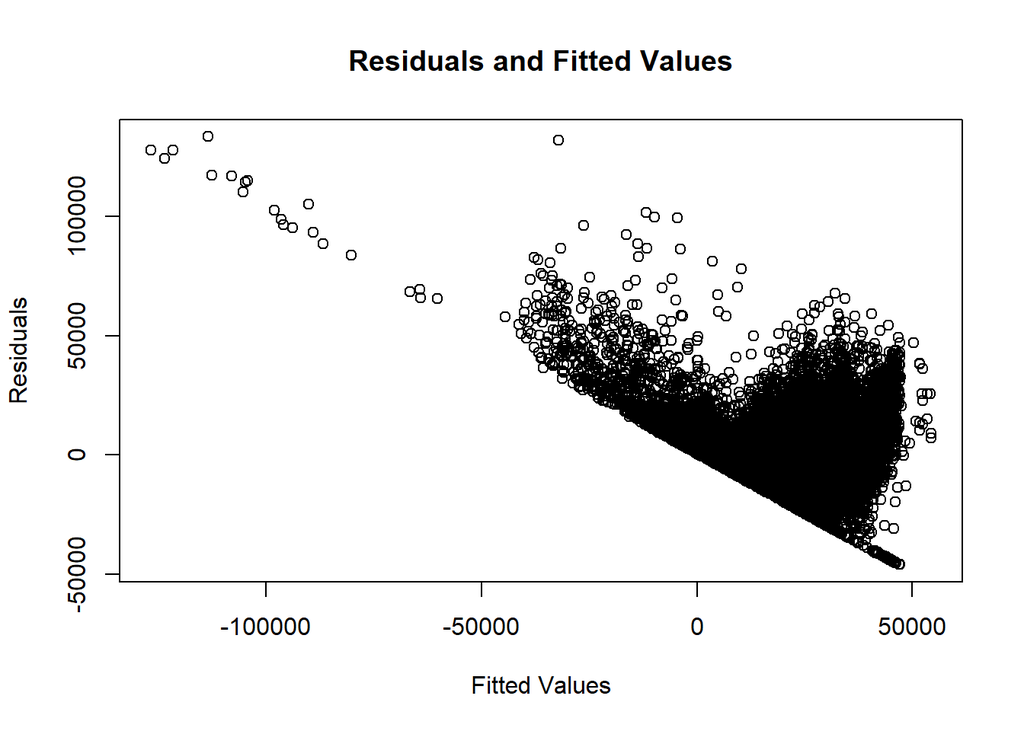

```r
model <- lm(price ~ year + odometer + cylinders + condition + fuel + transmission + drive + size + type, data = df)

plot(model$fitted.values, model$residuals,
     xlab = "Fitted Values", ylab = "Residuals",
     main = "Residuals and Fitted Values")
```

The Residuals and Fitted Values plot demonstrates the residuals in comparison to the the fitted values from the linear regression model. Some kind of a linear relationship is demonstrated by the plot as the points do not go below a certain defined line.

We expect to see no clear patterns in the plot, which indicates that the linear regression model is appropriate for the data. If there is a clear pattern, it suggests that the linear regression model may not be appropriate.

**Normal Q Q Plot**

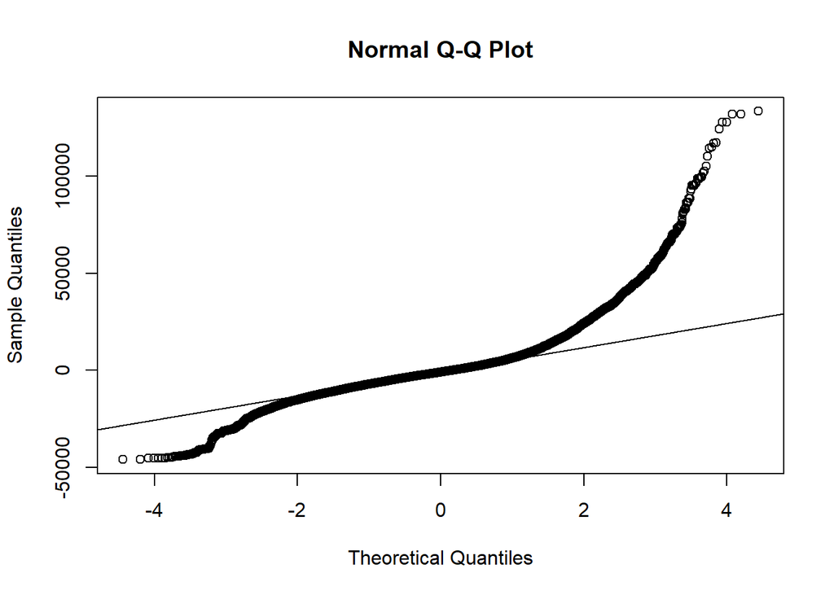

```r
qqnorm(model$residuals)
qqline(model$residuals)
```

**Scale Location Plot**

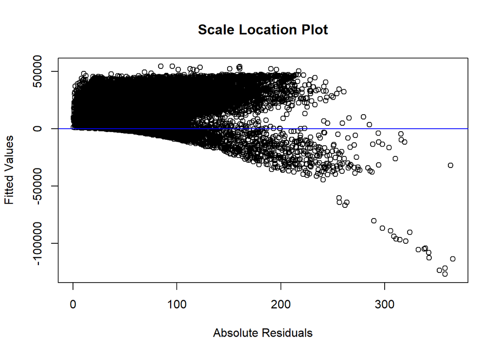

```r
plot(sqrt(abs(model$residuals)), model$fitted.values,
     xlab = "Absolute Residuals", ylab = "Fitted Values",
     main = "Scale Location Plot")

abline(lm(sqrt(abs(model$residuals)) ~ model$fitted.values), col = "blue")
```

**Residuals and Leverage Plot**

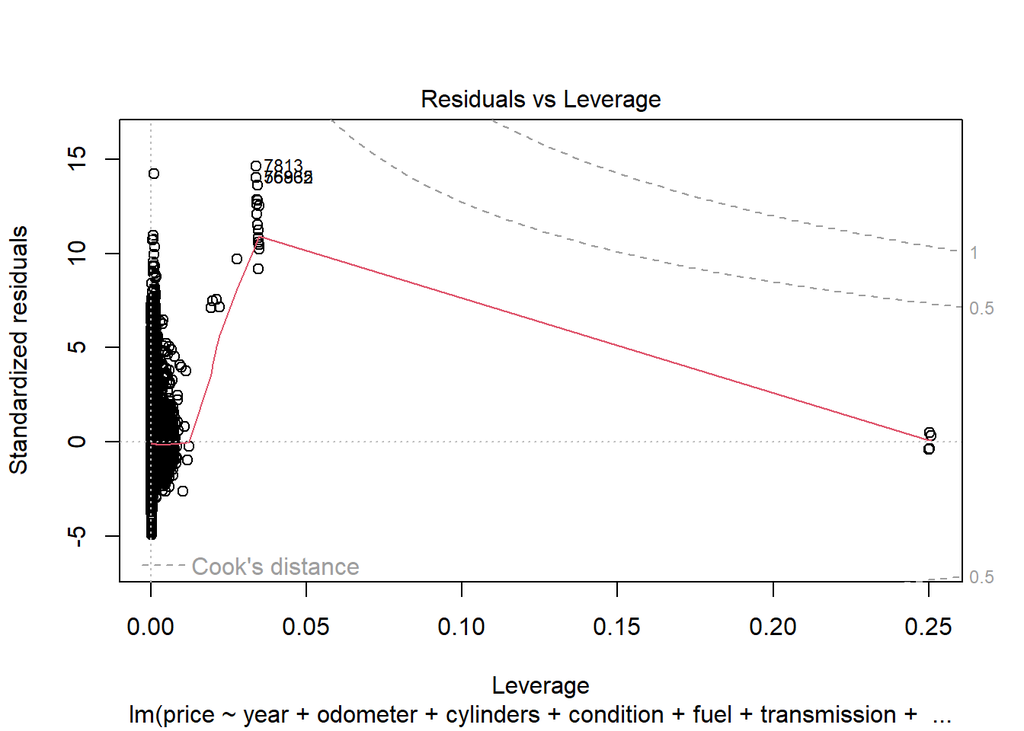

```r
plot(model, which = 5)
```